# Análise Preditiva de Óbitos Por Doenças Crônicas não Transmitíveis

## 5.16. Gráfico Apresenta os 10 Munícios com Mariores Números de Óbitos

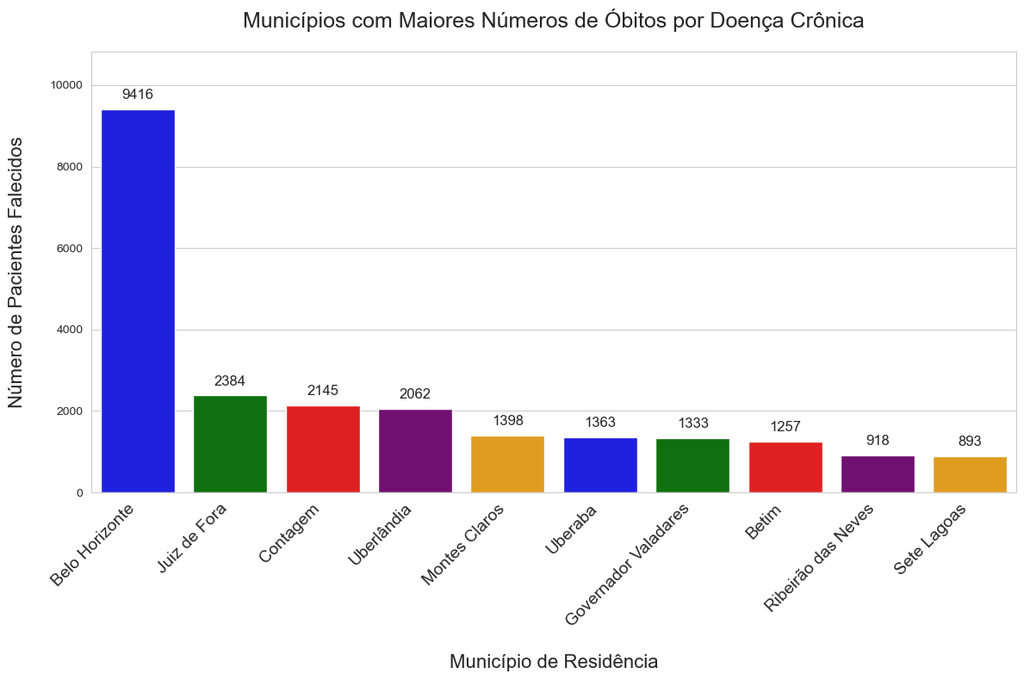

```python
# Gráfico para apresentar os 10 Municípios com Maiores Números de Óbitos


# Configurando o tamanho do gráfico
plt.figure(figsize=(12, 8))

# Limitando o número de municípios exibidos no gráfico para os top 10
top_municipios = dados_obito_doenca_cronica['co_municipio_ibge_residencia'].value_counts().nlargest(10)


# Definindo cores personalizadas
cores_personalizadas = ["blue", "green", "red", "purple", "orange"]

# Usando o estilo "whitegrid"
sns.set_style("whitegrid")

print()

# Plotando o gráfico de contagem com os 10 Municípios com Maiores Números de Óbitos
sns.barplot(x=top_municipios.index, y=top_municipios.values, palette=cores_personalizadas)
plt.title('Municípios com Maiores Números de Óbitos por Doença Crônica', fontsize=18, pad=20)
plt.xlabel('Município de Residência', fontsize=16, labelpad=20)
plt.ylabel('Número de Pacientes Falecidos', fontsize=16, labelpad=20)

# Definindo os rótulos do eixo x como os nomes dos municípios
plt.xticks(range(len(top_municipios.index)), top_municipios.index, rotation=45, ha='right', fontsize=14)

# Adicionando os valores no topo das barras
for index, value in enumerate(top_municipios.values):
    plt.text(index, value + 500, str(value), ha='center', va='top', fontsize=12)

# Ajustando os limites do eixo Y para aumentar o espaço acima da barra mais alta
max_height = max(dados_obito_doenca_cronica['co_municipio_ibge_residencia'].value_counts().values[:10])
plt.ylim(0, max_height * 1.15)  # Aumenta o limite superior para criar mais espaço

plt.tight_layout()
plt.show()
print()
```

## 5.17. Gráfico Apresenta as 2 Principais Doenças Crônica com Obito por Município

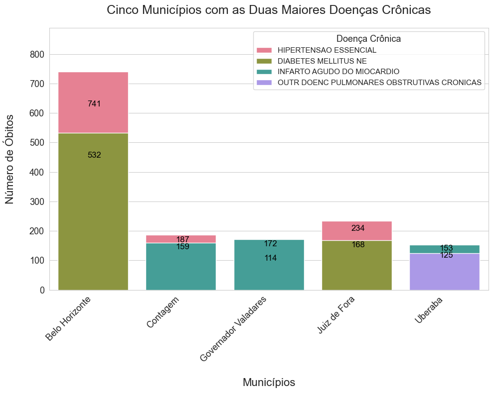

```
Município: Belo Horizonte, Doenças: HIPERTENSAO ESSENCIAL, Óbitos: 741
Município: Belo Horizonte, Doenças: DIABETES MELLITUS NE, Óbitos: 532
Município: Contagem, Doenças: HIPERTENSAO ESSENCIAL, Óbitos: 187
Município: Contagem, Doenças: INFARTO AGUDO DO MIOCARDIO, Óbitos: 159
Município: Governador Valadares, Doenças: INFARTO AGUDO DO MIOCARDIO, Óbitos: 172
Município: Governador Valadares, Doenças: DIABETES MELLITUS NE, Óbitos: 114
Município: Juiz de Fora, Doenças: HIPERTENSAO ESSENCIAL, Óbitos: 234
Município: Juiz de Fora, Doenças: DIABETES MELLITUS NE, Óbitos: 168
Município: Uberaba, Doenças: INFARTO AGUDO DO MIOCARDIO, Óbitos: 153
Município: Uberaba, Doenças: OUTR DOENC PULMONARES OBSTRUTIVAS CRONICAS, Óbitos: 125
```

```python
print()

# Configurando o tamanho do gráfico
plt.figure(figsize=(10, 8))

# Agrupando os dados por município e doença crônica, contando o número de óbitos para cada combinação
dados_agrupados = dados_obito_doenca_cronica.groupby(['co_municipio_ibge_residencia', 'categoria_cid_causa_basica']).size().reset_index(name='num_obitos')

# Para cada município, encontrar as 2 doenças crônicas com o maior número de óbitos
top_2_doencas_por_municipio = dados_agrupados.groupby('co_municipio_ibge_residencia').apply(lambda x: x.nlargest(2, 'num_obitos')).reset_index(drop=True)

# Ordenando os municípios pelas duas maiores doenças
ordenado_por_doencas = top_2_doencas_por_municipio.groupby('co_municipio_ibge_residencia').sum().nlargest(5, 'num_obitos').index

# Selecionando apenas os 5 principais municípios
top_5_municipios = top_2_doencas_por_municipio[top_2_doencas_por_municipio['co_municipio_ibge_residencia'].isin(ordenado_por_doencas)]

# Definindo uma paleta de cores com cores distintas para cada doença crônica
paleta = sns.color_palette("husl", len(top_5_municipios['categoria_cid_causa_basica'].unique()))

# Usando o estilo "whitegrid"
sns.set_style("whitegrid")

# Plotando o gráfico com as barras na vertical e usando a paleta personalizada
ax = sns.barplot(x='co_municipio_ibge_residencia', y='num_obitos', hue='categoria_cid_causa_basica', data=top_5_municipios, dodge=False, palette=paleta)

# ajustamos os limites do eixo y para aumentar o espaço acima da barra mais alta
max_height = max([p.get_height() for p in ax.patches])
ax.set_ylim(0, max_height * 1.2)  # valor para aumentar o limite superior para criar mais espaço

plt.title('Cinco Municípios com as Duas Maiores Doenças Crônicas', fontsize=18, pad=20)
plt.xlabel('Municípios', fontsize=16, labelpad=20)
plt.ylabel('Número de Óbitos', fontsize=16, labelpad=20)
plt.legend(title='Doença Crônica', title_fontsize='13', fontsize='11')

# Aumentando os valores de x (nome dos municípios) e y (números de óbitos)
plt.xticks(rotation=45, ha='right', fontsize=13)
plt.yticks(fontsize=13)

# Adicionando o número total de mortos no topo de cada barra com fonte Arial preta
for p in ax.patches:
    width = p.get_width()
    height = p.get_height()

    if height > 0:  # Verifica se o valor é válido

        # Calculando a coordenada y centralizada para cada faixa de cor
        y_coord = (height / 1.2)  # Calcula o topo da barra

        # Ajustando a posição do texto
        ax.annotate(f'{int(height)}', (p.get_x() + width / 2, y_coord), ha='center', fontsize=12, fontweight='normal', fontfamily='Arial', color='black', xytext=(2, 2), textcoords='offset points')

plt.tight_layout()
plt.show()

# Relatório Final
for index, row in top_5_municipios.iterrows():
    print(f"Município: {row['co_municipio_ibge_residencia']}, Doenças: {row['categoria_cid_causa_basica']}, Óbitos: {row['num_obitos']}")
```

### 5.11. Análise de Correlação entre Variáveis no Contexto de Óbitos por Doenças Crônicas

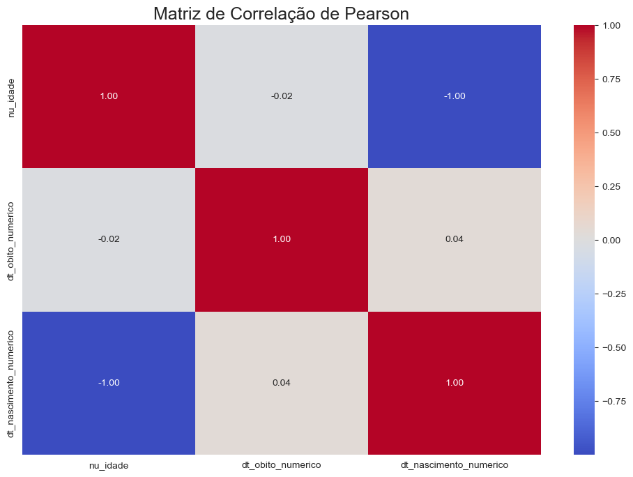

```python
import pandas as pd

# Seleciona apenas as colunas dos tipos desejados
dados_numericos = dados_obito_doenca_cronica.select_dtypes(include=['int32', 'datetime64[ns]'])

# Converte as datas para um formato numérico
dados_numericos['dt_obito_numerico'] = dados_numericos['dt_obito'].astype('int64')  # Converte a data do óbito para timestamp
dados_numericos['dt_nascimento_numerico'] = dados_numericos['dt_nascimento'].astype('int64')  # Converte a data de nascimento para timestamp

# Remove as colunas originais de datas
dados_numericos = dados_numericos.drop(columns=['dt_obito', 'dt_nascimento'])

# Calcula a matriz de correlação de Pearson
matriz_correlacao = dados_numericos.corr(method='pearson')

# Agora, matriz_correlacao contém os coeficientes de correlação de Pearson entre todas as variáveis numéricas
plt.figure(figsize=(12, 8))
sns.heatmap(matriz_correlacao, annot= True, cmap='coolwarm', fmt='.2f', annot_kws={"size": 10})
plt.title('Matriz de Correlação de Pearson', fontsize=18)
```

### Análise da Correlação:

1. **Correlação entre Idade e Data de Nascimento**:
   - Alta correlação negativa (-1.00) entre a idade do paciente e sua data de nascimento, indicando que à medida que a idade aumenta, a data de nascimento recua no tempo, o que é esperado e confirma a integridade dos dados.
2. **Correlação entre Data do Óbito e Idade**:
   - Correlação negativa muito baixa (-0.02) entre a data do óbito e a idade do paciente, indicando uma relação praticamente inexistente entre essas variáveis, sugerindo que a idade do paciente não está linearmente relacionada à data de óbito. Isso pode indicar que outros fatores, não apresentados nesses dados, além da idade, podem influenciar a mortalidade por doenças crônicas.
3. **Correlação entre Data do Óbito e Data de Nascimento**:
   - Correlação positiva muito baixa (0.04) entre a data do óbito e a data de nascimento do paciente, sugerindo uma relação praticamente inexistente entre essas variáveis e que não estão linearmente relacionadas.

### 5.12. "Análise da Distribuição da Idade dos Pacientes Falecidos ao Longo do Tempo"

[figure not shown]

```python
import matplotlib.pyplot as plt
import seaborn as sns
import matplotlib.ticker as mtick

# Reordenando os dados para garantir que a barra masculino apareça primeiro
dados_obito_doenca_cronica['sg_sexo'] = pd.Categorical(dados_obito_doenca_cronica['sg_sexo'], categories=['Masculino', 'Feminino'], ordered=True)


# Configurando o tamanho do gráfico
plt.figure(figsize=(10, 6))

# Usando o estilo "whitegrid"
#sns.set_style("whitegrid")

# Configurando o tamanho do gráfico
#plt.figure(figsize=(12, 8))

# Criando o gráfico de distribuição da idade ao longo do tempo
sns.histplot(data=dados_obito_doenca_cronica, x='nu_idade', hue='sg_sexo', kde=True, color='lightblue')

# Definindo os intervalos desejados no eixo x
plt.xticks(range(0, dados_obito_doenca_cronica['nu_idade'].max()+1, 10))

# Adicionando título e rótulos aos eixos
plt.title('Distribuição da Idade dos Pacientes Falecidos ao Longo do Tempo por Sexo', fontsize=18, pad=20)
plt.xlabel('Idade', fontsize=14, labelpad=20)
plt.ylabel('Número de Pacientes', fontsize=14, labelpad=20)

# Adicionando legenda manualmente
plt.legend(title='Sexo', loc='upper right', labels=['Masculino', 'Feminino'])

# Exibindo o gráfico
plt.show()
```